# Day5_4. Titanic 탐색적 데이터 분석

# 1. 라이브러리 임포트

- numpy, pandas, matplotlib, seaborn

```python
import numpy as np
import pandas as pd
import matplotlib.pyplot as plt
import seaborn as sns
%matplotlib inline
```

# 2. 데이터세트 불러오기

- train: 학습데이터세트 불러오기

> 주의: 데이터세트의 위치 확인하기

```python
pwd
```

```python
#train data set 불러오기
train = pd.read_csv('./data/train.csv')
```

```python
train.head()
```

# 3. 데이터 탐색

## 3.1) 기본 정보 확인

데이터의 기본 정보를 확인하고 결측값이 얼마나 있는지 확인한다. **판다스에서 기억해야 메서드들!!**

- **info ()** : 총 데이터 건수, 데이터 타입, null 건수를 알고 싶다.
- **describe()** : 칼럼별 숫자형 데이터값은 n-percentile 분포 확인 가능( 4분위수)
- Series객체에 **.value_counts()**: 해당 컬럼값의 유형(dtype)과 건수 확인 가능
- isnull().sum() : 결측값 확인

```python
train.info()
```

```python
#결측값 확인
train.isnull().sum()
```

```python
#데이터들의 기본통계 보기
train.describe()
```

## 3.2) Feature(변수)의 분석

- 각 피쳐의 데이터의 속성값 빈도를 파악한다.

### (1) 범주형 변수(정성 데이터, 명목변수/서열변수)

- Survived, Sex, Pclass, Embarked
- value_counts()
- countplot()

```python
#Survived 빈도분석
train['Survived'].value_counts()

#train.Survived.value_counts()
```

```python
#Survived 빈도분석 시각화
sns.countplot( data=train, x='Survived')
```

```python
#Plass빈도분석
train.Pclass.value_counts()
```

```python
#Plass빈도분석 시각화
sns.countplot( data=train, x='Pclass')
```

```python
#Sex
print(train.Sex.value_counts())
sns.countplot(x='Sex', data=train)
```

```python
print(train.Embarked.value_counts())
sns.countplot(x='Embarked', data=train)
```

### 연속형 변수

- Age, SibSp, Parch, Fare
- histogram을 통해 분포 파악
  - bins: x축의 그룹 수 (default: 10)

```python
#나이 분포 파악
train['Age'].plot.hist(bins=30)
plt.xlabel('Age')
```

```python
#SibSp와 Parch 동시에 그려보자

f, ax = plt.subplots(1,2,figsize=(15,5))

ax[0].set_title('SibSp')
train['SibSp'].plot.hist(bins=20, ax=ax[0])

ax[1].set_title('Parch')
train['Parch'].plot.hist(bins=20, ax=ax[1], color ='r')
```

```python
#fare
train['Fare'].plot.hist(bins=30)
```

## 3.3) Target 변수(목적변수) - Survived 분석

- 전체 생존률은 얼마일까?
  - 하나의 열에 2개의 파이차트를 그려보자.
    - fig, axes = plt.subplots(nrows=1, ncols=2)
    - autopct: 부채꼴 안에 표시될 숫자의 형식을 지정함. (소수점 한자리까지 표시)(auto percent)

```python
#한줄에 2개의 차드를 그리도록 하고 크기를 설정했음.
fig,axes = plt.subplots(1,2)

#첫번째 pie차트는 남자승객의 생존율
train['Survived'][train['Sex']=='male'].value_counts().plot.pie(autopct = '%.1f%%', ax=axes[0])

#두번째 pieck차트는 여자 승객의 생존율
train['Survived'][train['Sex']=='female'].value_counts().plot.pie(autopct = '%.1f%%', ax=axes[1])
plt.show()
```

**차트 변형하기**

- 설정 추가해보기
  - figsize: 차트 크기 설정
  - explode: 데이터를 튀어나오게 하는 정도 표시
    - 부채꼴이 차트 중심에서 벗어나는 정도 (list)
  - shadow : 음영 넣기 (True)
  - set_title(): 차트 제목 넣기.

```
fig,axes = plt.subplots(1,2, figsize = (10,5))

#첫번째 pie차트는 남자승객의 생존율
train['Survived'][train['Sex']=='male'].value_counts().plot.pie(explode=[0,0.1], autopct = '%.1f%%', ax=axes[0],shadow=True)

#두번째 pieck차트는 여자 승객의 생존율
train['Survived'][train['Sex']=='female'].value_counts().plot.pie(explode=[0,0.1], autopct = '%.1f%%', ax=axes[1],shadow=True)

#차트 제목 넣기
axes[0].set_title('Survived (Male)')
axes[1].set_title('Survived (female)')

plt.show()
```

```python
%matplotlib inline
#한줄에 2개의 차드를 그리도록 하고 크기를 설정했음.

fig,axes = plt.subplots(1,2, figsize = (10,5))

#첫번째 pie차트는 남자승객의 생존율
train['Survived'][train['Sex']=='male'].value_counts().plot.pie(explode=[0,0.1], autopct = '%1.1f%%', ax=axes[0])

#두번째 pieck차트는 여자 승객의 생존율
train['Survived'][train['Sex']=='female'].value_counts().plot.pie(explode=[0,0.2], autopct = '%.1f%%', ax=axes[1])

#train['Survived'][train['Sex']=='female'].value_counts().plot.pie()
axes[0].set_title('Survived (Male)')
axes[1].set_title('Survived (female)')
plt.show()
```

## 3.4) Feature와 Tarket변수와 관계 (목적변수&설명변수)

- countplot: feature의 항목별 갯수 파악
  - 인수: x(x축 기준), hue(세부 구분자), data(차트그릴 데이터프레임)
- barplot으로 생존률을 살펴보자

### 3.4.1) Pclass와 Survived와의 관계

```python
sns.countplot(x='Pclass', hue='Survived', data=train)
```

** Pclass와 생존과 관계

- 1에서 3으로 늘어날수록 생존률이 낮아짐.

### 3.4.2) Sex와 Survived와의 관계

```python
#Groupby 사용하여 데이터 보기 (판다스)
#성별로 생존자 숫자 보기

train.groupby(['Sex','Survived'])['Survived'].count()
```

```python
#성별, 생존자 countplot 그려보기
#seabon의 countplot이용하기

sns.countplot(x='Sex',hue='Survived',data=train)
plt.title("male & survived")
```

```python
#성별로 생존률 파악
sns.barplot(x='Sex',y='Survived',data=train)
```

**성별과 생존과의 관계

- 남성은 생존률이 낮고, 여성은 생존률이 높음.
- 성별은 아주 중요한 특징량임을 알 수 있음.

### 3.4.3)Embarked와 Survived와의 관계

```python
sns.countplot(x='Embarked', hue='Survived', data=train)
```

**Embarked와 생존률과의 관계 S와 Q는 생존률이 낮고, C는 생존률이 높음.

### 3.4.4) Age와 Survived와의 관계

**히스토그램인수**

**[복습]** -loc : 특정값 가져오기

- 인수 1개: loc[인덱스(행)]
- 인수 2개: loc[인덱스(행), '컬럼명' (열)]
- 조건 인수: loc[조건], loc[조건,'컬럼명']

```python
plt.hist(train.loc[train['Survived']==0, 'Age'],bins=30, alpha=0.5,label='0')
plt.hist(train.loc[train['Survived']==1, 'Age'], bins=30, alpha=0.5,label='1')
plt.xlabel('Age')
plt.ylabel('count')
plt.legend(title='Survived')
plt.show()
```

연령과 생존과의 관계연령별 생존률 파악

- 나이가 어린 사람들과 나이가 많은 사람의 생존율이 20대와 30대에 비해 상대적으로 높음

### 3.4.5)SibSp와 Survived와의 관계

- 막대그래프 (countplot)
  - x: data의 변수 이름
  - hue: 2개의 범주화 변수를 겹쳐서 그릴때 사용
- 참고
  - legend: 범례

```python
sns.countplot(x='SibSp', hue='Survived', data=train)
plt.legend(loc='upper right', title='Survived') # 범례를 오른쪽에 적어주기
```

**SibSP와 목적변수와의 관계 결과**

- 0인 데이터, 3이상인 데이터는 생존률이 낮다.
- 1과 2인 경우 상대적으로 생존률이 높다.

### 3.4.6)Parch와 Survived와의 관계

```python
sns.countplot(x='Parch', hue='Survived', data=train)
plt.legend(loc='upper right', title='Survived')
```

**Parch와 생존과의 관계**

- Parch가 0인 경우와 4이상일 경우 생존률이 낮음
- Parch 1, 2, 3인 경우 상대적으로 생존률이 높음.

> **SibSp와 Parch는 유사한 패턴을 보임. 향후 하나의 변수로 만들어 볼 수 있음**

```python
#참고: alpha는 투명도(0~1)
plt.hist(train.loc[train['Survived']==0, 'Fare'], bins=25, alpha =0.5, label='0')
plt.hist(train.loc[train['Survived']==1, 'Fare'], bins=25, alpha =0.5, label='1')
plt.xlabel('Fare')
plt.ylabel('count')
plt.legend(title='Survived')

plt.xlim(-5,250) # x축 범위 지정
```

운임이 10이하인 승객의 사망률이 높음

## 3.5) 질적 변수의 수치화 - Sex, Embarked

- Sex는 male/female로 표시되므로 상관관계를 보기 위해 0/1로 치환하기
- Sex2 속성으로 넣기

```
train['Sex2'] = train['Sex'].replace(['male','female'],[0,1])
```

```python
train['Sex2'] = train['Sex'].replace(['male','female'],[0,1])
```

- Embarked의 SCQ를 0,1,2로 치환함.
- Embarked2 속성으로 넣기

```
train['Embarked2']=train['Embarked'].replace(['S', 'C','Q'], [0,1,2] )
```

```python
train['Embarked2']=train['Embarked'].replace(['S', 'C','Q'], [0,1,2] )
```

## 3.6) 상관분석 시각화

### 피어슨 상관계수

피쳐와 타겟 변수(생존여부)의 상관관계를 살펴본다.

- 피어슨 상관계수 사용
- 연속형 데이터에 대해서만 사용 가능

```python
train_corr = train.corr(method='pearson')
```

```python
train_corr
```

### 특정 변수 사이의 상관계수 구하기

```python
# 특정 변수 사이의 상관계수 구하기
train['Survived'].corr(train['Pclass'])
```

## 3.7) 산점도로 상관분석 시각화하기

```python
# 변수들 간의 산점도 안에서 'Survived' 비교
sns.pairplot(train, hue='Survived')
plt.show()
```

## 3.8) 히트맵으로 상관관계 살펴보기

다음 피쳐들에 대해 히트맵을 그려본다.

- Survived, Sex2, Age, Pclass, SibSp, Parch, Fare. Embarked

```python
heatmap_data = train[['Survived','Sex2','Age','Pclass','SibSp','Parch','Fare', 'Embarked2']]
sns.heatmap(heatmap_data.astype(float).corr())
```

**히트맵 보기 좋게 만들기**

- cmap: 히트맵의 색을 설정 (plt.cm.RdBu)
- annotation: 값을 주석으로 넣기 (True)

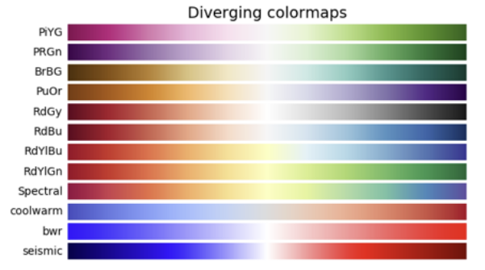

```
heatmap_data = train[['Survived','Sex2','Age2','Pclass','SibSp','Parch','Fare', 'Embarked2']]
colormap=plt.cm.RdBu
sns.heatmap(heatmap_data.astype(float).corr(), cmap=colormap, annot=True,)
plt.show()
```

```python
heatmap_data = train[['Survived','Sex2','Age','Pclass','SibSp','Parch','Fare','Embarked2']]
colormap=plt.cm.RdBu
sns.heatmap(heatmap_data.corr(), linewidths=0.1, vmax=1.0, square =True, cmap=colormap, linecolor = 'white', annot=True, annot_kws = {"size":10})
plt.show()
```

**정리**

- Survived와 상관관계 높은 변수: Sex, Pclass, Fare, Embarked, Age 순임.